# FI 362 — Chapter 1: Financial Time Series and Their Characteristics

An Applied, Step-by-Step Companion to Tsay (2010), *Analysis of Financial Time Series*

Author

Mehman Ismayilli — Shanghai Jiao Tong University

Published

July 1, 2026

**How to use this notebook**

This notebook is your **lab manual** for Chapter 1 of Tsay. It follows the book section by section, but instead of just *stating* a formula it *computes* it on real market data — the S&P 500, Apple (AAPL) and Microsoft (MSFT) — so you can see the theory breathe.

**The rhythm of every section is the same:**

1. 📖 **Theory** — the formula and the intuition (in plain, sometimes cheeky, English).
2. 💻 **Code** — runnable R with a comment on (almost) every line. Copy it, run it, *change* it.
3. 🎯 **Your turn** — a small task. Swap in a different stock or index and redo it.

Read the idea, run the block, then break it on purpose to see what happens. That is how you learn econometrics — not by watching, but by *doing*.

# 1 Getting set up (do this once)

Before any econometrics, we need three things: **the packages**, **the data**, and **a working directory** that points R at the data. Let’s do them in order.

## 1.1 Step 1 — Install the packages you are missing

R ships with a powerful base, but we lean on a few specialised packages. The block below is **idempotent**: it checks what you already have and installs only what is *missing*. Run it once; on later runs it does nothing and finishes instantly.

```r
# A tiny helper: TRUE if a package is installed, FALSE otherwise.
# requireNamespace() checks availability WITHOUT attaching the package,
# so it is the clean way to test "do I have this?".
have <- function(pkg) requireNamespace(pkg, quietly = TRUE)

# The packages this notebook uses. (Comment = what each one gives us.)
needed <- c(
  "ggplot2",   # modern, layered plotting
  "moments",   # skewness() / kurtosis() — we ALSO hand-code these to learn
  "tseries",   # jarque.bera.test() for normality
  "zoo",       # date handling / rolling windows
  "knitr",     # kable() pretty tables in the rendered HTML
  "MASS",      # fitdistr() — maximum-likelihood fitting (Student-t etc.)
  "mvtnorm"    # multivariate normal/t densities for Section 5
)

# Which of the needed packages are NOT yet installed?
missing <- needed[!vapply(needed, have, logical(1))]

# Install the missing ones from the main CRAN mirror. If you are OFFLINE this
# will fail quietly and only the sections needing that package are affected.
if (length(missing)) {
  message("Installing: ", paste(missing, collapse = ", "))
  install.packages(missing, repos = "https://cloud.r-project.org")
} else {
  message("All required packages already installed. Nothing to do. ✅")
}
```

**Installing a package by hand (if the block above is blocked)**

On some lab machines automatic installation is disabled. In that case, run this **one line at a time** in the Console for any package you are missing, e.g.

```r
install.packages("mvtnorm")
```

and answer “yes” if asked to use a personal library.

Now **attach** (load) the packages so their functions are on the search path:

```r
library(ggplot2)   # plotting grammar: ggplot() + geom_*()
library(moments)   # skewness(), kurtosis()
library(tseries)   # jarque.bera.test()
library(zoo)       # as.Date helpers, rollapply()
library(knitr)     # kable()
library(MASS)      # fitdistr()
library(mvtnorm)   # dmvnorm(), rmvnorm()

theme_set(theme_minimal(base_size = 12))  # a clean default look for all ggplots
```

## 1.2 Step 2 — Download the data from the course webpage

All examples use a small set of CSV files I prepared for you (daily Yahoo Finance prices, **Jan 2000 – mid 2026**, already adjusted for splits and dividends). Download the `data/` folder from my course page:

The files you should end up with:

| File | What’s inside |
| --- | --- |
| `stocks_adjclose.csv` | Daily adjusted close: AAPL, MSFT, AXP, CAT, SBUX |
| `indices_adjclose.csv` | Daily adjusted close: 11 global indices (S&P 500, NASDAQ, …) |
| `indices_monthly.csv` | Month-end adjusted close of those indices |
| `sp500_monthly.csv` | Month-end S&P 500 only |
| `metadata.csv` | A directory: ticker → name, region, asset class, sample span |

## 1.3 Step 3 — Tell R where the data lives (the working directory)

The **working directory** is the folder R treats as “here”. You point R at the *project*, and then refer to files by short relative names.

```r
# ── ONLY for students running interactively in RStudio ────────────────────────
# Replace the path below with the folder that CONTAINS your data/ folder.
# Windows users: either use forward slashes "/" or double backslashes "\\".

setwd("~/Documents/FI362")        # macOS / Linux example
# setwd("C:/Users/you/Documents/FI362")   # Windows example

getwd()                            # print it back to confirm you are in the right place
list.files("data")                 # you should see the CSV files listed
```

**Best practice: never hard-code a path in a shared file**

`setwd()` is fine when *you* run code interactively. But a notebook that other people render should **find** its data, not assume a path. The next block does exactly that — it looks in the usual places and stops with a helpful message if it can’t find the folder. This is why the rest of the notebook *just works* regardless of whose machine it runs on.

```r
# Robustly locate the data/ folder whether this file is rendered from the
# Chapter-1 folder, the project root, or sourced interactively.
data_dir <- local({
  candidates <- c("../data", "data", file.path(getwd(), "data"))   # places to look
  hit <- candidates[file.exists(file.path(candidates, "stocks_adjclose.csv"))]
  if (!length(hit))
    stop("Could not find the data/ folder. Did you download it (Step 2) ",
         "and set the working directory (Step 3)?")
  normalizePath(hit[1])            # return a clean absolute path to the winner
})
cat("Using data in:", data_dir, "\n")
```

```
#> Using data in: /Users/econ0757/Library/CloudStorage/GoogleDrive-ismayilli.mehman@gmail.com/My Drive/SJTU/FE/data
```

```r
# One small reader so we never repeat ourselves. check.names = FALSE keeps
# column names exactly as in the file (e.g. "S&P500"-style names survive).
read_prices <- function(file) {
  df <- read.csv(file.path(data_dir, file), check.names = FALSE)
  df$Date <- as.Date(df$Date)      # turn the text "2000-01-03" into a real Date
  df
}

stocks    <- read_prices("stocks_adjclose.csv")    # daily stock prices  (wide)
indices   <- read_prices("indices_adjclose.csv")   # daily index prices  (wide)
idx_month <- read_prices("indices_monthly.csv")    # month-end indices   (wide)
sp_month  <- read_prices("sp500_monthly.csv")      # month-end S&P 500
meta      <- read.csv(file.path(data_dir, "metadata.csv"))

# Peek at the first few rows so you can SEE the shape of the data.
kable(head(stocks, 4), caption = "stocks_adjclose.csv — daily adjusted close prices.")
```

stocks_adjclose.csv — daily adjusted close prices.

| Date | AAPL | MSFT | AXP | CAT | SBUX |
| --- | --- | --- | --- | --- | --- |
| 2000-01-03 | 0.83772 | 35.444 | 32.150 | 12.521 | 2.2736 |
| 2000-01-04 | 0.76710 | 34.246 | 30.936 | 12.360 | 2.2016 |
| 2000-01-05 | 0.77832 | 34.607 | 30.151 | 12.650 | 2.2304 |
| 2000-01-06 | 0.71097 | 33.448 | 30.765 | 13.293 | 2.3111 |

Our **running examples** throughout: the index `SP500`, and the two stocks `AAPL` and `MSFT`. Every computation is *column-agnostic*, so to switch to, say, `CAT` or `NASDAQ` you change a single string.

# 2 Financial assets

📖 **Theory.** A *financial time series* is the record, over time, of the price (or return, or volatility) of a **financial asset** — a contract with a monetary value. Our toolbox in this course covers the big families:

- **Equities** — a share of ownership in a firm (AAPL, MSFT). Residual claim, unlimited upside, limited downside (you can lose at most your stake).
- **Equity indices** — a rules-based *portfolio* of stocks (S&P 500, NASDAQ, Nikkei). A thermometer for a whole market.
- **Fixed income, FX, commodities, derivatives** — bonds, currencies, oil, options/futures. Same statistical toolkit, different economics.

What makes financial series *special* (and fun) is summarised by Tsay’s mantra: **returns, not prices, are the object of study**, and those returns are **not** the tame i.i.d. Normal variables of a first stats course. Let’s meet the data.

💻 **Code — the investable universe we have on disk:**

```r
# metadata.csv is a self-describing directory of every series in the folder.
kable(meta[, c("symbol", "name", "region", "asset_class", "rows", "start", "end")],
      caption = "The course universe: 11 global indices and 5 US stocks, 2000–2026.")
```

The course universe: 11 global indices and 5 US stocks, 2000–2026.

| symbol | name | region | asset_class | rows | start | end |
| --- | --- | --- | --- | --- | --- | --- |
| ^GSPC | SP500 | United States | Equity index | 6641 | 2000-01-03 | 2026-05-29 |
| ^IXIC | NASDAQ | United States | Equity index | 6641 | 2000-01-03 | 2026-05-29 |
| ^DJI | DowJones | United States | Equity index | 6641 | 2000-01-03 | 2026-05-29 |
| ^FTSE | FTSE100 | United Kingdom | Equity index | 6719 | 2000-01-04 | 2026-05-29 |
| ^GDAXI | DAX | Germany | Equity index | 6747 | 2000-01-03 | 2026-05-29 |
| ^FCHI | CAC40 | France | Equity index | 6784 | 2000-01-03 | 2026-05-29 |
| ^N225 | Nikkei225 | Japan | Equity index | 6589 | 2000-01-04 | 2026-06-01 |
| ^HSI | HangSeng | Hong Kong | Equity index | 6583 | 2000-01-03 | 2026-05-29 |
| 000001.SS | SSEComposite | China | Equity index | 6519 | 2000-01-04 | 2026-05-29 |
| ^KS11 | KOSPI | South Korea | Equity index | 6603 | 2000-01-04 | 2026-06-01 |
| ^BSESN | Sensex | India | Equity index | 6596 | 2000-01-03 | 2026-05-29 |
| AAPL | AAPL | United States | Stock | 6641 | 2000-01-03 | 2026-05-29 |
| MSFT | MSFT | United States | Stock | 6641 | 2000-01-03 | 2026-05-29 |
| AXP | AXP | United States | Stock | 6641 | 2000-01-03 | 2026-05-29 |
| CAT | CAT | United States | Stock | 6641 | 2000-01-03 | 2026-05-29 |
| SBUX | SBUX | United States | Stock | 6641 | 2000-01-03 | 2026-05-29 |

A first look at three *price* series on one chart. Notice they live on wildly different scales — that alone is a reason we will soon switch to returns.

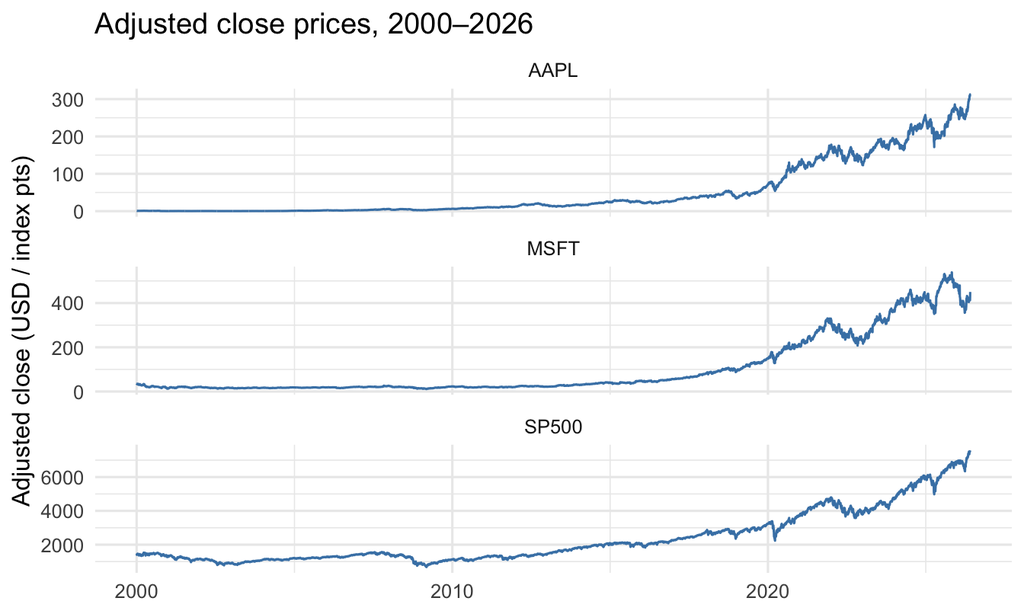

```r
# Pull the three running-example price columns into one tidy frame for ggplot.
px <- data.frame(
  Date  = stocks$Date,                 # common daily calendar
  AAPL  = stocks$AAPL,                 # Apple adjusted close
  MSFT  = stocks$MSFT,                 # Microsoft adjusted close
  SP500 = indices$SP500[match(stocks$Date, indices$Date)]  # align S&P by date
)

# Plot each on its own panel (free y-axis) so scale differences don't hide shape.
px_long <- reshape(px, direction = "long",
                   varying = c("AAPL","MSFT","SP500"),
                   v.names = "Price", timevar = "Series",
                   times = c("AAPL","MSFT","SP500"))
ggplot(px_long, aes(Date, Price)) +
  geom_line(colour = "steelblue") +
  facet_wrap(~ Series, scales = "free_y", ncol = 1) +   # separate y per series
  labs(title = "Adjusted close prices, 2000–2026",
       y = "Adjusted close (USD / index pts)", x = NULL)
```

🎯 **Your turn.** Look up two of your own tickers in `meta` (try `CAT`, `SBUX`, `NASDAQ`, `HangSeng`). Re-plot them. Which has the longest sample? Which looks the most “explosive”?

# 3 Asset returns

Prices are awkward: they trend, they are non-stationary, and “$5” means something different for a $10 stock than a $1000 one. **Returns** fix all of this — they are scale-free and (much closer to) stationary. Tsay defines several flavours; we build each one and *check the identities numerically*.

## 3.1 Simple returns (one period)

📖 **Theory.** Hold an asset from $t-1$ to $t$. The **simple gross return** is
$$1+R_t=\frac{P_t}{P_{t-1}},\qquad\text{and the **simple net return** is } R_t=\frac{P_t}{P_{t-1}}-1.$$
A gross return of $1.01$ is a $1\%$ gain. Simple returns are what your brokerage statement shows.

💻 **Code.**

```r
# Two tiny helpers, written from the definitions so there is no magic.
lag1       <- function(x) c(NA, head(x, -1))   # shift series down by one (P_{t-1})
simple_ret <- function(p) p / lag1(p) - 1      # R_t = P_t / P_{t-1} - 1

# Apply to the S&P 500 and keep price + return side by side.
sp <- data.frame(Date = indices$Date, Price = indices$SP500)
sp <- sp[is.finite(sp$Price), ]                # drop any missing prices first
sp$R <- simple_ret(sp$Price)                   # simple NET return, R_t

kable(head(sp, 6), digits = 5,
      caption = "S&P 500: price and one-period simple net return R_t.")
```

S&P 500: price and one-period simple net return R_t.

| Date | Price | R |
| --- | --- | --- |
| 2000-01-03 | 1455.2 | NA |
| 2000-01-04 | 1399.4 | -0.03834 |
| 2000-01-05 | 1402.1 | 0.00192 |
| 2000-01-06 | 1403.4 | 0.00096 |
| 2000-01-07 | 1441.5 | 0.02709 |
| 2000-01-10 | 1457.6 | 0.01119 |

The picture that justifies the whole switch — price *trends*, return *mean-reverts around zero*:

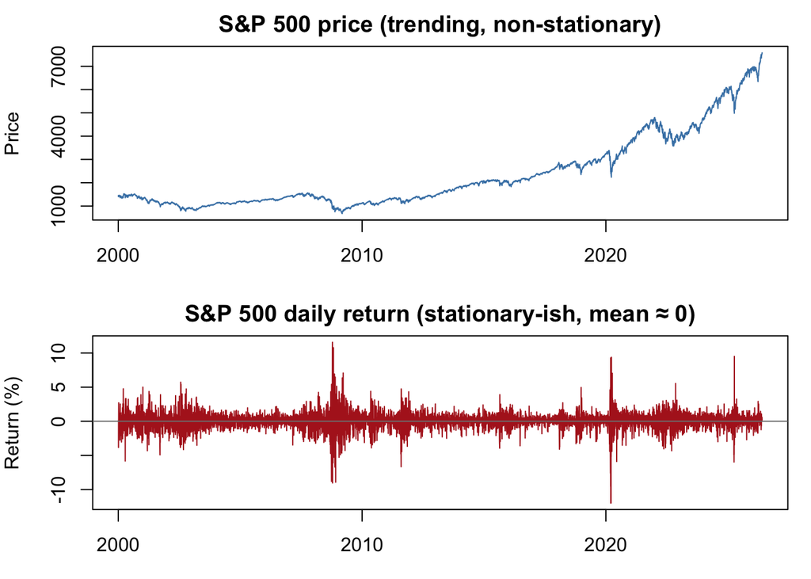

```r
op <- par(mfrow = c(2, 1), mar = c(3, 4, 2, 1))   # 2 stacked panels
plot(sp$Date, sp$Price, type = "l", col = "steelblue",
     xlab = "", ylab = "Price", main = "S&P 500 price (trending, non-stationary)")
plot(sp$Date, 100 * sp$R, type = "l", col = "firebrick",
     xlab = "", ylab = "Return (%)", main = "S&P 500 daily return (stationary-ish, mean ≈ 0)")
abline(h = 0, col = "grey50")                     # reference line at zero
```

```r
par(op)                                           # restore plotting layout
```

## 3.2 Multi-period returns & compounding

📖 **Theory.** Hold for $k$ periods. Gross returns **multiply**:
$$1+R_t[k]=\prod_{j=0}^{k-1}\bigl(1+R_{t-j}\bigr)=\frac{P_t}{P_{t-k}}.$$
So “compounding” is literally just the telescoping price ratio.

💻 **Code — verify the identity on a 5-day window:**

```r
w <- sp[2:6, ]                          # five consecutive trading days
gross_prod <- prod(1 + w$R)             # LHS: product of (1 + R_t)
direct     <- sp$Price[6] / sp$Price[1] # RHS: P_t / P_{t-k}, the direct ratio
c(`compounded product` = gross_prod,
  `direct price ratio` = direct,
  difference           = gross_prod - direct)   # ≈ 0 ⇒ identity holds
```

```
#> compounded product direct price ratio         difference
#>         1.0016e+00         1.0016e+00        -2.2204e-16
```

## 3.3 Continuous compounding and the number $e$

📖 **Theory.** Split the year into $m$ equal periods at annual rate $r$; $1 grows to $(1+r/m)^m$. Let $m\to\infty$ and you get **continuous compounding**:
$$\lim_{m\to\infty}\Bigl(1+\frac{r}{m}\Bigr)^{m}=e^{r}.$$
This limit is *why* log returns exist — see the next subsection.

💻 **Code — watch the limit happen:**

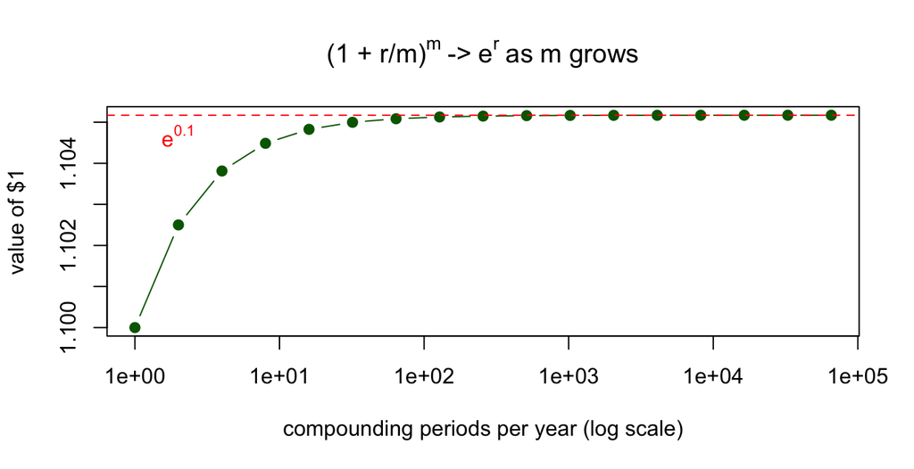

```r
r  <- 0.10                              # 10% annual rate, $1 for one year
ms <- 2^(0:16)                          # compounding freq: 1, 2, 4, …, 65536
val <- (1 + r / ms)^ms                  # value after one year at each frequency
plot(ms, val, log = "x", type = "b", pch = 19, col = "darkgreen",
     xlab = "compounding periods per year (log scale)", ylab = "value of $1",
     main = expression("(1 + r/m)"^m ~ "->" ~ e^r ~ "as m grows"))
abline(h = exp(r), lty = 2, col = "red")          # the limit e^{0.1}
text(2, exp(r), expression(e^0.1), pos = 1, col = "red")
```

## 3.4 Log (continuously compounded) returns

📖 **Theory.** The **log return** is
$$r_t=\ln(1+R_t)=\ln P_t-\ln P_{t-1}.$$
Its superpower: it is **additive across time**, $r_t[k]=\sum_{j=0}^{k-1}r_{t-j}$, which turns messy products into tidy sums and is exactly what makes time-series modelling tractable.

💻 **Code.**

```r
log_ret <- function(p) c(NA, diff(log(p)))   # r_t = ln P_t - ln P_{t-1}
sp$r <- log_ret(sp$Price)                     # add log return to our S&P frame

# Additivity check: sum of daily log returns == log of the price ratio.
c(`sum of daily log r` = sum(w <- sp$r[2:6]),
  `log of price ratio` = log(direct),
  difference           = sum(sp$r[2:6]) - log(direct))
```

```
#> sum of daily log r log of price ratio         difference
#>         1.6342e-03         1.6342e-03        -3.6104e-16
```

**Simple vs. log — when does the distinction matter?** For small moves $r_t\approx R_t$; they part company only in the tails (big days).

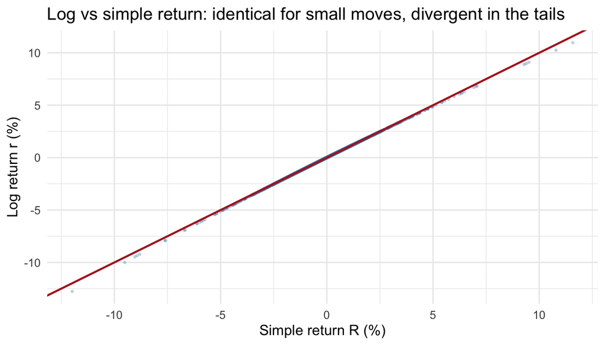

```r
d <- na.omit(data.frame(R = sp$R, r = sp$r))      # drop the first NA row
ggplot(d, aes(100 * R, 100 * r)) +
  geom_point(alpha = 0.25, size = 0.6, colour = "steelblue") +
  geom_abline(slope = 1, intercept = 0, colour = "firebrick", linewidth = 0.8) +
  labs(x = "Simple return R (%)", y = "Log return r (%)",
       title = "Log vs simple return: identical for small moves, divergent in the tails")
```

## 3.5 Portfolio returns

📖 **Theory.** For a portfolio with weights $w_i$, **simple** returns aggregate *exactly* across assets,
$$R_{p,t}=\sum_i w_i R_{i,t},$$
while **log** returns aggregate only *approximately*, $r_{p,t}\approx\sum_i w_i r_{i,t}$. (The asymmetry is the mirror image of the time-aggregation story.)

💻 **Code — equal-weight AAPL/MSFT, exact vs approximate:**

```r
two <- na.omit(data.frame(                    # align the two stocks, drop NAs
  Date = stocks$Date,
  Ra   = simple_ret(stocks$AAPL),             # AAPL simple return
  Rm   = simple_ret(stocks$MSFT),             # MSFT simple return
  ra   = log_ret(stocks$AAPL),                # AAPL log return
  rm   = log_ret(stocks$MSFT)                 # MSFT log return
))
w <- c(0.5, 0.5)                              # equal weights

Rp        <- w[1] * two$Ra + w[2] * two$Rm   # EXACT portfolio simple return  R_p
rp_exact  <- log(1 + Rp)                      # its TRUE log return  ln(1 + R_p)
rp_approx <- w[1] * two$ra + w[2] * two$rm   # the APPROXIMATION  w1*r1 + w2*r2

# Put the two log-return series side by side with their gap, in % points.
cmp <- data.frame(Date     = two$Date,
                  exact_pct = 100 * rp_exact,            # ln(1 + sum w_i R_i)
                  approx_pct = 100 * rp_approx,          # sum w_i r_i
                  error_pct  = 100 * (rp_exact - rp_approx))

# Show the first few days so you can SEE the two columns nearly coincide.
kable(head(cmp, 6), digits = 5,
      caption = "Equal-weight AAPL/MSFT portfolio: exact vs approximate daily log return (%).")
```

Equal-weight AAPL/MSFT portfolio: exact vs approximate daily log return (%).

| Date | exact_pct | approx_pct | error_pct |
| --- | --- | --- | --- |
| 2000-01-04 | -6.08602 | -6.12208 | 0.03606 |
| 2000-01-05 | 1.25099 | 1.25079 | 0.00020 |
| 2000-01-06 | -6.18947 | -6.22929 | 0.03982 |
| 2000-01-07 | 2.97710 | 2.96324 | 0.01386 |
| 2000-01-10 | -0.51617 | -0.52399 | 0.00782 |
| 2000-01-11 | -3.91375 | -3.92257 | 0.00882 |

```r
# Two summary numbers we will quote in the discussion below.
port_corr   <- cor(rp_exact, rp_approx)           # how tightly the two agree
port_maxerr <- 100 * max(abs(rp_exact - rp_approx))  # worst single-day gap, %-pts
c(correlation = port_corr, `max abs error (%-pts)` = port_maxerr)
```

```
#>           correlation max abs error (%-pts)
#>               0.99915               6.25528
```

**What the numbers say.** Across all 6,640 trading days the exact and approximate portfolio log returns correlate 0.99915 — visually a single line. Yet the agreement is *not* perfect: the worst single-day discrepancy is 6.255 percentage points, and it lands (as theory predicts) on the most violent day in the sample. The lesson is practical: at **daily** frequency you may add log returns across assets and lose almost nothing, which is why risk systems do it all the time; but the approximation $r_{p,t}\approx\sum_i w_i r_{i,t}$ is an *approximation*, and it decays exactly when you need precision most — in a crash. Simple returns, by contrast, aggregate across assets with **zero** error, always.

🎯 **Your turn.** Build a **60/40 AAPL/MSFT** portfolio (`w <- c(0.6, 0.4)`). Does the maximum approximation error grow or shrink? Now add `SBUX` as a third asset with weights summing to 1 and redo it.

# 4 Review of statistical distributions and their moments

Before we can say a return is “fat-tailed” we need the vocabulary of distributions. This section is the **statistics refresher** that Tsay puts up front — done concretely so the abstractions stick.

## 4.1 Densities, CDFs, and quantiles

📖 **Theory.** A continuous random variable $X$ has a **pdf** $f(x)$ and **cdf** $F(x)=\Pr(X\le x)=\int_{-\infty}^x f(u)\,du$. The **quantile** function is the inverse, $F^{-1}(p)$. In R every distribution comes as a quartet of functions with prefixes **d/p/q/r** (density / probability / quantile / random):

💻 **Code — the d-p-q-r quartet, on the standard Normal:**

```r
dnorm(0)          # density f(0) of N(0,1): the peak height ≈ 0.399
```

```
#> [1] 0.39894
```

```r
pnorm(1.96)       # cdf F(1.96): probability a N(0,1) is below 1.96 (≈ 0.975)
```

```
#> [1] 0.975
```

```r
qnorm(0.975)      # quantile: the value with 97.5% mass below it (≈ 1.96) — inverse of above
```

```
#> [1] 1.96
```

```r
set.seed(1)       # make the random draw reproducible
rnorm(5)          # five random N(0,1) draws
```

```
#> [1] -0.62645  0.18364 -0.83563  1.59528  0.32951
```

Notice `pnorm` and `qnorm` are inverses: `qnorm(pnorm(1.96))` returns `1.96`.

## 4.2 Moments: mean, variance, skewness, kurtosis

📖 **Theory.** The **$\ell$-th moment** about the mean is $m_\ell=\mathbb E[(X-\mu)^\ell]$. The headline four:

- **Mean** $\mu=\mathbb E[X]$ — the center.
- **Variance** $\sigma^2=\mathbb E[(X-\mu)^2]$ — the spread; $\sigma$ is volatility.
- **Skewness** $S=\mathbb E[(X-\mu)^3]/\sigma^3$ — asymmetry ($<0$: long left tail).
- **Kurtosis** $K=\mathbb E[(X-\mu)^4]/\sigma^4$ — tail heaviness; **excess kurtosis** is $K-3$ (the Normal has $K=3$, so $K-3>0$ means *fatter than Normal*).

Their sample estimators (Tsay’s $1/(T-1)$ scaling):
$$\hat S=\frac{1}{(T-1)\hat\sigma^3}\sum_{t=1}^{T}(x_t-\bar x)^3,\qquad
\hat K=\frac{1}{(T-1)\hat\sigma^4}\sum_{t=1}^{T}(x_t-\bar x)^4.$$

💻 **Code — hand-code the moments, then check against the `moments` package:**

```r
# Sample moments EXACTLY as on the slides (T-1 scaling). Written out so you
# can see the sum-of-powers structure rather than trusting a black box.
samp_stats <- function(x) {
  x  <- x[is.finite(x)]                         # ignore NA / Inf
  T  <- length(x)                               # sample size
  m  <- mean(x)                                 # mean  = sum(x)/T
  s  <- sqrt(sum((x - m)^2) / (T - 1))          # sd    (square root of variance)
  sk <- sum((x - m)^3) / ((T - 1) * s^3)        # skewness, standardised 3rd moment
  ku <- sum((x - m)^4) / ((T - 1) * s^4)        # kurtosis, standardised 4th moment
  data.frame(n = T, mean = m, sd = s,
             skew = sk, exkurt = ku - 3,        # report EXCESS kurtosis (K - 3)
             min = min(x), max = max(x))
}

spr <- 100 * na.omit(sp$r)                      # S&P daily log returns, in %
mine <- samp_stats(spr)                         # our hand-coded version
pkg  <- c(skew = skewness(spr), kurt = kurtosis(spr))  # moments:: package
kable(mine, digits = 4, caption = "S&P 500 daily % log returns — sample moments (hand-coded).")
```

S&P 500 daily % log returns — sample moments (hand-coded).

| n | mean | sd | skew | exkurt | min | max |
| --- | --- | --- | --- | --- | --- | --- |
| 6640 | 0.0249 | 1.2167 | -0.3486 | 10.644 | -12.765 | 10.957 |

```r
cat(sprintf("Cross-check vs moments::  skew %.4f (pkg %.4f) | exkurt %.4f (pkg K-3 %.4f)\n",
            mine$skew, pkg["skew"], mine$exkurt, pkg["kurt"] - 3))
```

```
#> Cross-check vs moments::  skew -0.3486 (pkg -0.3486) | exkurt 10.6437 (pkg K-3 10.6458)
```

**Reading the four numbers** (S&P 500, daily, %):

- **Mean 0.0249%/day** is tiny — but compounded over ~252 trading days it is about **6.3%/year**, the equity risk premium hiding in plain sight. Returns *look* like noise day to day; the drift only shows up over long horizons.
- **Volatility 1.217%/day** annualises (multiply by $\sqrt{252}$) to roughly **19%/year** — the familiar “the market does about 15–20% vol” figure, recovered from first principles.
- **Skewness -0.349** is negative: the left tail is longer, i.e. the biggest *down* days (worst: -12.77%) are larger in magnitude than the biggest *up* days (best: 10.96%). Crashes are sharper than rallies.
- **Excess kurtosis 10.64** is the headline. A Normal has 0; here it is *enormous*. It says the fourth moment is dominated by a handful of extreme days — those -12.8% / 11.0% observations would be essentially impossible under a Normal with this standard deviation. This single number is the statistical fingerprint of “fat tails,” and the rest of the chapter is about taking it seriously.

🎯 **Your turn.** Run `samp_stats(100 * na.omit(log_ret(stocks$AAPL)))`. Is AAPL more or less fat-tailed than the S&P 500? More or less skewed? (Single-stock returns are usually *more* kurtotic than a diversified index — confirm it.)

# 5 Distributions of returns

📖 **Theory.** What probability law generates returns? Tsay surveys the candidates:

- **Normal** — analytically lovely, but assigns *absurdly* low probability to crashes. A 5σ daily move “should” happen once in ~7,000 years; markets do it every few years.
- **Lognormal** — assume *gross* returns are lognormal, i.e. *log* returns are Normal. Cleaner, but still thin-tailed.
- **Student-$t$** — symmetric but **fat-tailed**, controlled by degrees of freedom $\nu$. As $\nu\to\infty$ it becomes Normal; small $\nu$ ⇒ heavy tails. This is usually the workhorse for daily returns.
- **Mixtures / stable laws** — even richer tail behaviour.

Let’s *see* the failure of the Normal and the rescue by the $t$.

💻 **Code — histogram with a fitted Normal overlay (the Normal is too thin):**

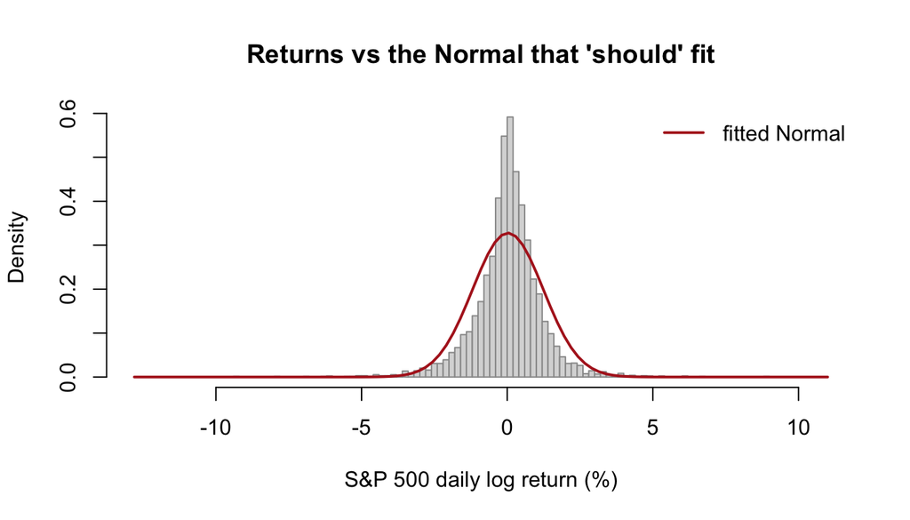

```r
hist(spr, breaks = 120, freq = FALSE, col = "grey85", border = "grey60",
     xlab = "S&P 500 daily log return (%)", main = "Returns vs the Normal that 'should' fit")
curve(dnorm(x, mean(spr), sd(spr)), add = TRUE, col = "firebrick", lwd = 2)  # MLE Normal
legend("topright", lwd = 2, col = "firebrick", legend = "fitted Normal", bty = "n")
```

The empirical histogram is **taller in the middle and fatter in the tails** than the red Normal — the signature of excess kurtosis.

💻 **Code — the Normal Q-Q plot makes the fat tails unmistakable:**

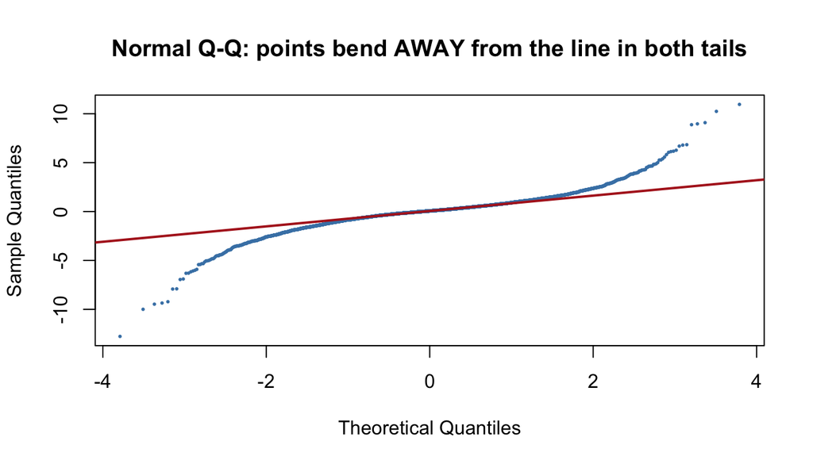

```r
qqnorm(spr, pch = 16, cex = 0.4, col = "steelblue",
       main = "Normal Q-Q: points bend AWAY from the line in both tails")
qqline(spr, col = "firebrick", lwd = 2)        # the line a true Normal would follow
```

💻 **Code — fit a Student-$t$ by maximum likelihood and compare tails:**

```r
# Standardise returns to (roughly) unit scale so fitdistr's t-fit is stable.
z <- spr / sd(spr)
fit_t <- fitdistr(z, "t", start = list(m = 0, s = 1, df = 5))  # ML fit of scaled-t
nu <- fit_t$estimate["df"]                       # estimated degrees of freedom
cat(sprintf("Estimated Student-t degrees of freedom: nu = %.2f\n", nu))
```

```
#> Estimated Student-t degrees of freedom: nu = 2.65
```

```r
cat("Small nu (here single digits) = FAT tails. Normal corresponds to nu = Inf.\n")
```

```
#> Small nu (here single digits) = FAT tails. Normal corresponds to nu = Inf.
```

**Interpreting $\hat\nu=2.65$.** This is a single number that captures the entire fat-tail story. Recall a Student-$t$ has theoretical excess kurtosis $6/(\nu-4)$ for $\nu>4$; plugging in our estimate gives an implied excess kurtosis of about **infinite (ν ≤ 4 ⇒ the 4th moment does not even exist)**. In words: the data want tails so heavy that the fourth moment is, strictly, infinite — extreme days dominate any finite sample. A Normal is the limit $\nu\to\infty$; we are nowhere near it. That is why every risk model in later chapters reaches for a $t$ (or something heavier) rather than a Gaussian for the daily shock.

## 5.1 Testing normality formally

📖 **Theory.** Under normality, the standardised sample skewness and excess kurtosis are asymptotically Normal:
$$\hat S\sim N\!\Bigl(0,\tfrac{6}{T}\Bigr),\qquad \hat K-3\sim N\!\Bigl(0,\tfrac{24}{T}\Bigr).$$
The **Jarque–Bera** statistic combines them,
$$\mathrm{JB}=\frac{\hat S^2}{6/T}+\frac{(\hat K-3)^2}{24/T}\xrightarrow{d}\chi^2_2,$$
so a large JB (small $p$-value) **rejects** normality.

💻 **Code — hand-code the JB tests across ALL series, then cross-check:**

```r
# Test statistics for skew, excess kurtosis, and their JB combination.
norm_tests <- function(x) {
  x  <- x[is.finite(x)]; T <- length(x)
  s  <- samp_stats(x)
  t_sk <- s$skew   / sqrt(6  / T)               # z-stat for skewness, H0: S = 0
  t_ku <- s$exkurt / sqrt(24 / T)               # z-stat for excess kurtosis, H0: K-3 = 0
  JB   <- t_sk^2 + t_ku^2                        # Jarque-Bera = sum of the two squared z's
  data.frame(skew = s$skew, exkurt = s$exkurt,
             JB = JB, p_JB = 1 - pchisq(JB, df = 2))   # p-value from chi-square(2)
}

# Build % log returns for every stock and index, then test each.
all_prices <- cbind(indices[ , -1],
                    stocks[match(indices$Date, stocks$Date), -1])   # align on index dates
ret_list   <- lapply(all_prices, function(p) 100 * log_ret(p))      # % log returns per column

jb <- do.call(rbind, lapply(names(ret_list), function(nm)
  cbind(Series = nm, norm_tests(ret_list[[nm]]))))
kable(jb, digits = c(0, 3, 3, 1, 4),
      caption = "Skewness, excess kurtosis, and Jarque–Bera (p ≈ 0 ⇒ reject Normal).")
```

Skewness, excess kurtosis, and Jarque–Bera (p ≈ 0 ⇒ reject Normal).

| Series | skew | exkurt | JB | p_JB |
| --- | --- | --- | --- | --- |
| SP500 | -0.343 | 10.895 | 31719.4 | 0 |
| NASDAQ | -0.097 | 6.524 | 11337.3 | 0 |
| DowJones | -0.321 | 13.157 | 46182.4 | 0 |
| FTSE100 | -0.371 | 8.540 | 19894.2 | 0 |
| DAX | -0.172 | 6.124 | 10313.1 | 0 |
| CAC40 | -0.212 | 6.721 | 12555.5 | 0 |
| Nikkei225 | -0.574 | 6.818 | 12225.9 | 0 |
| HangSeng | -0.051 | 7.147 | 13217.5 | 0 |
| SSEComposite | -0.339 | 5.679 | 8480.1 | 0 |
| KOSPI | -0.594 | 8.098 | 17332.1 | 0 |
| Sensex | -0.461 | 10.583 | 28882.6 | 0 |
| AAPL | -4.034 | 117.736 | 3706866.4 | 0 |
| MSFT | -0.045 | 8.687 | 20086.4 | 0 |
| AXP | 0.187 | 11.629 | 36029.1 | 0 |
| CAT | -0.093 | 4.587 | 5610.4 | 0 |
| SBUX | 0.163 | 9.905 | 26139.0 | 0 |

```r
# Sanity check our hand-coded JB against tseries::jarque.bera.test for the S&P.
jarque.bera.test(na.omit(sp$r))
```

```
#>
#>  Jarque Bera Test
#>
#> data:  na.omit(sp$r)
#> X-squared = 31490, df = 2, p-value <2e-16
```

**Reading the table.** The 5% critical value for a $\chi^2_2$ is only 5.99, yet **every** series in our global universe blows past it by orders of magnitude. The S&P 500 alone scores JB $=31,719$; the most extreme series is **AAPL** (JB $=3,706,866$), and even the *calmest*, **CAT**, still rejects with JB $=5,610$. Notice in the table that the `exkurt` column, not `skew`, is doing the heavy lifting — squaring a large excess kurtosis and dividing by the tiny variance $24/T$ produces an astronomical statistic. So normality fails *primarily through the tails*. This is *the* empirical fact that the rest of Tsay’s book is built to handle.

🎯 **Your turn.** Which series in the JB table is the *least* non-Normal (the smallest JB)? Indices are usually closer to Normal than single stocks — does your answer agree? Why would diversification pull a series toward Normal?

# 6 Multivariate returns

📖 **Theory.** Real portfolios hold *many* assets, so we need the **joint** distribution. For a vector of returns $\mathbf r_t=(r_{1t},\dots,r_{Nt})'$:

- **Mean vector** $\boldsymbol\mu=\mathbb E[\mathbf r_t]$.
- **Covariance matrix** $\boldsymbol\Sigma=\mathbb E[(\mathbf r_t-\boldsymbol\mu)(\mathbf r_t-\boldsymbol\mu)']$, whose $(i,j)$ entry is $\mathrm{Cov}(r_{it},r_{jt})$.
- **Correlation matrix** $\boldsymbol\rho$, the scale-free version, $\rho_{ij}=\sigma_{ij}/(\sigma_i\sigma_j)\in[-1,1]$.

Diversification, beta, CAPM, factor models — everything multivariate starts here.

💻 **Code — build the return matrix for AAPL, MSFT, S&P 500:**

```r
# Assemble a clean matrix of daily log returns for our three running examples.
mv <- na.omit(data.frame(
  AAPL  = log_ret(stocks$AAPL),
  MSFT  = log_ret(stocks$MSFT),
  SP500 = log_ret(indices$SP500[match(stocks$Date, indices$Date)])
))
R <- as.matrix(mv)                              # T x 3 numeric matrix of returns

mu  <- colMeans(R)                              # mean vector  (hat mu)
Sig <- cov(R)                                   # covariance matrix (hat Sigma)
Cor <- cor(R)                                   # correlation matrix (hat rho)

kable(t(data.frame(mean = mu)) * 100, digits = 4,
      caption = "Mean vector of daily % log returns.")
```

Mean vector of daily % log returns.

|  | AAPL | MSFT | SP500 |
| --- | --- | --- | --- |
| mean | 0.0892 | 0.0383 | 0.0249 |

```r
kable(Sig * 1e4, digits = 3,
      caption = "Covariance matrix (×10^4, i.e. in %^2 units).")
```

Covariance matrix (×10^4, i.e. in %^2 units).

|  | AAPL | MSFT | SP500 |
| --- | --- | --- | --- |
| AAPL | 6.227 | 2.182 | 1.704 |
| MSFT | 2.182 | 3.581 | 1.615 |
| SP500 | 1.704 | 1.615 | 1.480 |

```r
kable(Cor, digits = 3, caption = "Correlation matrix.")
```

Correlation matrix.

|  | AAPL | MSFT | SP500 |
| --- | --- | --- | --- |
| AAPL | 1.000 | 0.462 | 0.561 |
| MSFT | 0.462 | 1.000 | 0.701 |
| SP500 | 0.561 | 0.701 | 1.000 |

**Reading the three matrices.**

- **Mean vector.** AAPL averages 0.089%/day and MSFT 0.038%/day, both above the index’s 0.025%/day — the single-stock premia (and the extra risk that earns them).
- **Covariance → volatility.** The diagonal of $\hat\Sigma$ is variance; its square root, annualised, gives vols of about **40%** (AAPL), **30%** (MSFT) and **19%** (S&P 500). The index is the *least* volatile — diversification at work, since it is itself a basket.
- **Correlation.** Both stocks are tightly tied to the market: $\rho_{\text{AAPL,SP500}}=0.56$ and $\rho_{\text{MSFT,SP500}}=0.70$, while the two stocks correlate $0.46$ with each other.

That shared co-movement with the S&P 500 is not a coincidence — it is the single **common factor** (the market) that CAPM prices and that factor models decompose. You are looking at the raw material of every asset-pricing model in the course.

💻 **Code — visualise the joint cloud and a fitted bivariate-Normal contour:**

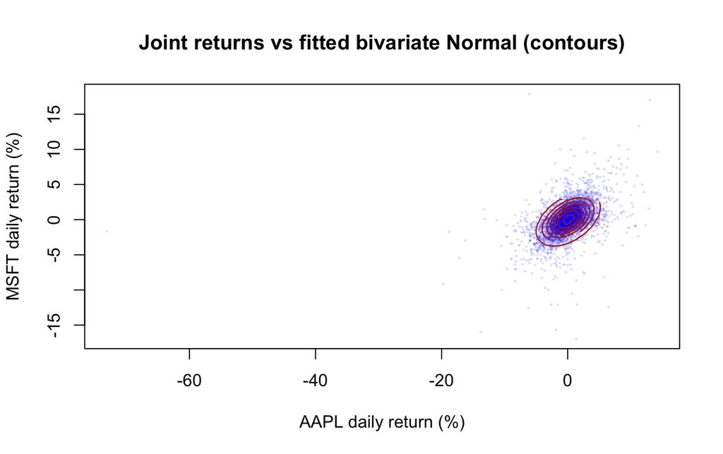

```r
# Scatter of AAPL vs MSFT daily % returns, with bivariate-Normal density contours
# implied by the sample mean & covariance — do the contours match the cloud?
xy <- 100 * R[, c("AAPL", "MSFT")]              # work in % units for readability
m2  <- colMeans(xy); S2 <- cov(xy)              # bivariate mean & covariance

# Grid over the plotting region, evaluate the fitted bivariate Normal density.
gx <- seq(min(xy[,1]), max(xy[,1]), length.out = 80)
gy <- seq(min(xy[,2]), max(xy[,2]), length.out = 80)
grid <- expand.grid(AAPL = gx, MSFT = gy)
grid$z <- dmvnorm(as.matrix(grid), mean = m2, sigma = S2)   # mvtnorm density

plot(xy, pch = 16, cex = 0.3, col = rgb(0, 0, 1, 0.15),
     xlab = "AAPL daily return (%)", ylab = "MSFT daily return (%)",
     main = "Joint returns vs fitted bivariate Normal (contours)")
contour(gx, gy, matrix(grid$z, 80, 80), add = TRUE, col = "firebrick", lwd = 1.2)
```

```r
# Quantify the tail failure: under a bivariate Normal the squared Mahalanobis
# distance is chi-square(2), so only 1% of days should fall outside the 99%
# ellipse. How many actually do?
md2      <- mahalanobis(xy, center = m2, cov = S2)   # squared Mahalanobis distance
thresh   <- qchisq(0.99, df = 2)                     # 99% ellipse cutoff
emp_tail <- 100 * mean(md2 > thresh)                 # empirical % beyond it
c(`Normal says (%)` = 1, `data shows (%)` = emp_tail)
```

```
#> Normal says (%)  data shows (%)
#>          1.0000          3.2982
```

**Quantifying the mismatch.** Under a genuine bivariate Normal, exactly **1%** of days should land outside the 99% probability ellipse. In the data, **3.3%** do — roughly 3.3× too many joint extremes. So fat tails are not just a one-asset curiosity: **crashes are joint events**, and AAPL and MSFT plunge *together* far more often than any Gaussian dependence structure would allow. This is precisely why portfolio risk cannot be captured by a covariance matrix alone, and why later chapters bring in copulas and multivariate-$t$ models.

🎯 **Your turn.** Add `CAT` (Caterpillar, an industrial) to the matrix `mv`. Is its correlation with the S&P 500 higher or lower than the two tech names? Industrials and tech load differently on the market — quantify it.

# 7 The likelihood of returns

📖 **Theory.** A **model** for returns is a probability density with parameters $\boldsymbol\theta$. Given data $r_1,\dots,r_T$, the **likelihood** is the joint density viewed as a function of $\boldsymbol\theta$. Under the i.i.d. assumption it factorises, and we work with the **log-likelihood** (sums beat products):
$$\ell(\boldsymbol\theta)=\sum_{t=1}^{T}\ln f(r_t\mid\boldsymbol\theta).$$
The **maximum-likelihood estimator (MLE)** is $\hat{\boldsymbol\theta}=\arg\max_{\boldsymbol\theta}\ell(\boldsymbol\theta)$ — the parameter values that make the data *least surprising*. This single idea powers nearly every estimator in the course (GARCH, factor models, copulas).

💻 **Code — write the Normal log-likelihood and confirm the textbook MLEs:**

```r
x <- na.omit(sp$r)                              # S&P daily log returns (decimals)

# Log-likelihood of an i.i.d. Normal sample, as a function of (mu, sigma).
loglik_norm <- function(par, data) {
  mu <- par[1]; sigma <- par[2]                 # unpack the two parameters
  if (sigma <= 0) return(-Inf)                  # sigma must be positive
  sum(dnorm(data, mean = mu, sd = sigma, log = TRUE))  # sum of log-densities
}

# Maximise it numerically (optim MINIMISES, so we minimise the NEGATIVE log-lik).
# x is captured by the closure below, so we don't pass it as an extra argument.
opt <- optim(par = c(mean(x), sd(x)), fn = function(p) -loglik_norm(p, x),
             method = "BFGS")
cat(sprintf("Numerical MLE:   mu = %.6f   sigma = %.6f\n", opt$par[1], opt$par[2]))
```

```
#> Numerical MLE:   mu = 0.000249   sigma = 0.012167
```

```r
# The textbook closed-form MLEs: mu_hat = sample mean, sigma_hat = sqrt(mean sq dev)
cat(sprintf("Closed-form MLE: mu = %.6f   sigma = %.6f\n",
            mean(x), sqrt(mean((x - mean(x))^2))))
```

```
#> Closed-form MLE: mu = 0.000249   sigma = 0.012166
```

The numerical optimiser lands on the analytic answer: $\hat\mu$ is the sample mean and $\hat\sigma^2$ is the (divide-by-$T$) sample variance. **You just re-derived the most famous MLE in statistics from scratch.**

💻 **Code — does a fat-tailed model *like the data better*? Compare via AIC:**

```r
# Fit a Normal and a (location-scale) Student-t by ML, then compare fit with AIC.
# Lower AIC = better trade-off of fit vs number of parameters.
fit_n <- fitdistr(x, "normal")                              # 2 params: mean, sd
fit_t <- fitdistr(x, "t", start = list(m = 0, s = sd(x), df = 5))  # 3 params

aic <- function(f) -2 * f$loglik + 2 * length(f$estimate)  # AIC = -2 logL + 2k
cat(sprintf("Normal : logL = %.1f , AIC = %.1f\n", fit_n$loglik, aic(fit_n)))
```

```
#> Normal : logL = 19854.9 , AIC = -39705.8
```

```r
cat(sprintf("Student: logL = %.1f , AIC = %.1f  (df = %.2f)\n",
            fit_t$loglik, aic(fit_t), fit_t$estimate["df"]))
```

```
#> Student: logL = 20823.1 , AIC = -41640.3  (df = 2.73)
```

```r
cat(sprintf("\nThe Student-t wins by %.0f AIC points — overwhelming evidence\n",
            aic(fit_n) - aic(fit_t)),
    "that returns are fat-tailed, not Normal.\n")
```

```
#>
#> The Student-t wins by 1934 AIC points — overwhelming evidence
#>  that returns are fat-tailed, not Normal.
```

**Reading the verdict.** Adding a single parameter — the degrees of freedom $\hat\nu=2.73$ — raises the log-likelihood from 19,855 to 20,823 and *lowers* the AIC by **1,934 points**. To calibrate how lopsided that is: a difference of 10 AIC points already makes one model ~150× more likely than the other; here the gap is in the *thousands*. There is no contest. The model the data actually prefer is heavy-tailed, with an estimated $\nu$ small enough that — using $6/(\nu-4)$ — the implied excess kurtosis is effectively infinite, matching the moment we measured by hand back in §4.2. This is the empirical content of “returns are not Normal,” stated in the rigorous language of likelihood rather than by eye.

🎯 **Your turn.** Repeat the Normal-vs-$t$ AIC comparison for **AAPL** and **MSFT** log returns. Which stock has the smaller estimated $\nu$ (the fattest tails)? Write one sentence interpreting it for an investor.

# 8 Empirical properties of returns: the stylised facts

📖 **Theory.** Decades of studies converge on a handful of **stylised facts** — properties that hold across assets, markets, and eras. Tsay’s list:

1. **Returns are nearly serially uncorrelated** (you can’t predict *direction* from the past) …
2. **… but volatility is highly persistent** — squared/absolute returns are strongly autocorrelated (**volatility clustering**: calm follows calm, storms follow storms).
3. **Fat tails** (excess kurtosis) — extreme moves are far more common than Normal.
4. **Mild negative skew** — crashes are sharper than rallies (the “leverage” effect).

These four facts are the *job description* for the GARCH, EVT and VaR models in the rest of the course. Let’s display all of them on one screen.

💻 **Code — the four stylised facts of the S&P 500, in one figure:**

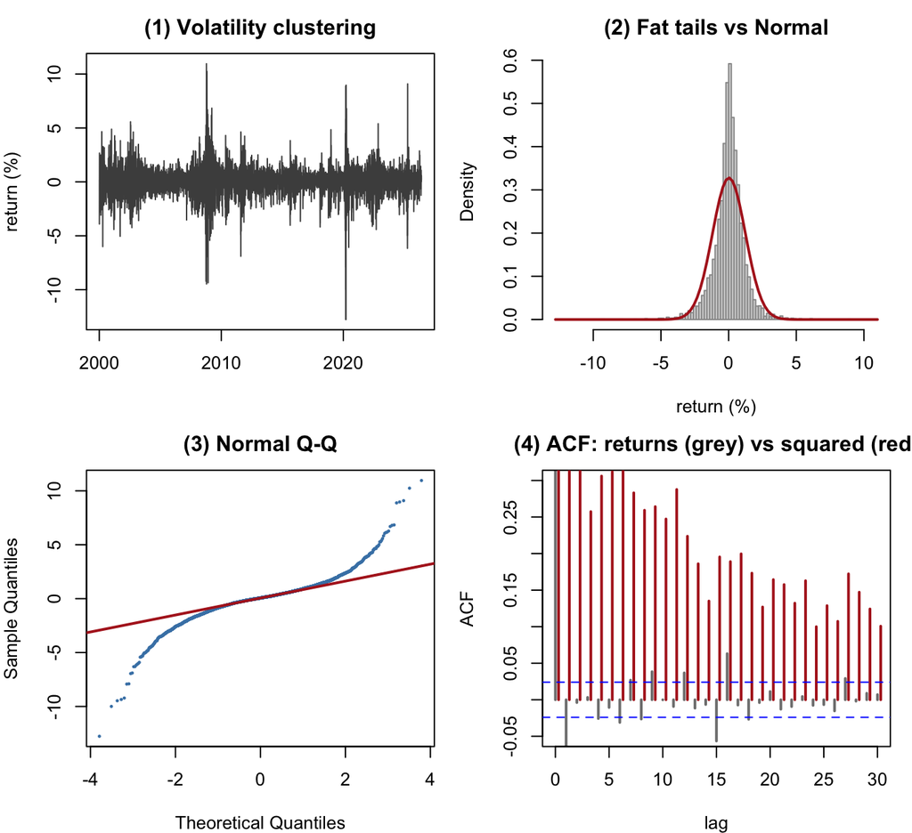

```r
rr  <- 100 * na.omit(sp$r)                      # S&P daily % log returns
dts <- sp$Date[is.finite(sp$r)]                 # matching dates

op <- par(mfrow = c(2, 2), mar = c(4, 4, 2.5, 1))   # 2x2 panel grid

## (1) Volatility clustering — bursts of large moves bunch together in time.
plot(dts, rr, type = "l", col = "grey30", xlab = "", ylab = "return (%)",
     main = "(1) Volatility clustering")

## (2) Fat tails — empirical histogram towers over the fitted Normal in the tails.
hist(rr, breaks = 120, freq = FALSE, col = "grey85", border = "grey60",
     xlab = "return (%)", main = "(2) Fat tails vs Normal")
curve(dnorm(x, mean(rr), sd(rr)), add = TRUE, col = "firebrick", lwd = 2)

## (3) Negative skew / heavy tails — Q-Q bends off the line, worse on the left.
qqnorm(rr, pch = 16, cex = 0.4, col = "steelblue", main = "(3) Normal Q-Q")
qqline(rr, col = "firebrick", lwd = 2)

## (4) The key contrast: ACF of returns (≈ 0) vs ACF of SQUARED returns (large).
a1 <- acf(rr,   lag.max = 30, plot = FALSE)     # autocorrelation of returns
a2 <- acf(rr^2, lag.max = 30, plot = FALSE)     # autocorrelation of squared returns
plot(a1$lag, a1$acf, type = "h", lwd = 2, col = "grey50", ylim = c(-0.05, 0.3),
     xlab = "lag", ylab = "ACF", main = "(4) ACF: returns (grey) vs squared (red)")
lines(a2$lag + 0.3, a2$acf, type = "h", lwd = 2, col = "firebrick")
abline(h = c(-1.96, 1.96) / sqrt(length(rr)), lty = 2, col = "blue")  # 5% bands
```

```r
par(op)
```

**Read-off (panel 4 is the punchline).** Put numbers on it. The $$2-standard-error band sits at $\pm0.024$. The lag-1 autocorrelation of **returns** is just -0.099 — economically nil, the market is (nearly) unforecastable in *direction*. But the lag-1 autocorrelation of **squared** returns is 0.313, and it stays positive and significant for *dozens* of lags (30 of the first 30 lags clear the band, versus 5 for raw returns). In one sentence: **you cannot forecast tomorrow’s sign, but you can absolutely forecast tomorrow’s *size*.** Calm clusters with calm and turbulence with turbulence — *volatility clustering*. That single asymmetry between panels — flat grey, persistent red — is the empirical seed of the entire ARCH/GARCH literature you will build from Chapter 3 onward.

🎯 **Your turn.** Reproduce this 2×2 figure for **AAPL** (swap `sp$r` for `log_ret(stocks$AAPL)`). Is the squared-return autocorrelation (panel 4) even stronger for a single stock than for the index? Then try a non-US index like `HangSeng` or `Nikkei225` — do the stylised facts cross borders?

# 9 Appendix — pulling fresh data yourself (optional)

You don’t need this to run the notebook (the CSVs already contain everything), but here is how the course data was built, in case you want a *different* ticker or a more recent sample. This block is set `eval=FALSE` so it never runs on render — copy it into your Console to use it.

```r
install.packages("quantmod")        # one-time, if not already installed
library(quantmod)

# Download Apple from Yahoo Finance into an xts object (auto.assign = FALSE
# returns it instead of silently creating a variable called AAPL).
aapl <- getSymbols("AAPL", src = "yahoo",
                   from = "2000-01-01", to = "2026-06-01",
                   auto.assign = FALSE)

head(aapl)                          # OHLCV + Adjusted columns
adj <- Ad(aapl)                     # Ad() extracts the split/dividend-adjusted close
ret <- diff(log(adj))               # daily log returns as an xts series
plot(ret, main = "AAPL daily log returns (live download)")
```

# 10 Key takeaways

1. **Returns, not prices.** Returns are scale-free and (roughly) stationary; prices trend and are not. *Always* model returns.
2. **Two definitions, one idea.** Simple returns *multiply* across time and *add* across assets exactly; log returns *add* across time exactly and across assets approximately. At daily frequency they are nearly interchangeable.
3. **Returns are not Normal.** Fat tails (large excess kurtosis), mild negative skew, and volatility clustering. Jarque–Bera rejects normality for *every* series in our global sample; a Student-$t$ beats the Normal decisively on AIC.
4. **Volatility is predictable; direction is not.** Returns are serially uncorrelated, but their *squares* are strongly autocorrelated. This is the empirical launch-pad for GARCH, EVT, and VaR in the chapters ahead.

**How to reproduce and extend**

Render with `quarto render FI362_Ch1_Supplement.qmd` (or click **Render** in RStudio). To change the running example, edit a single column name — `"SP500"` → `"NASDAQ"`, `"AAPL"` → `"CAT"`, etc. The code is deliberately column-agnostic so *your* analysis is one keystroke away.